# Statistical Analysis and Modeling in R

[Student Data Labs](https://studentdatalabs.com), Vision Zero Innovation Lab

In this demo, we’ll be using R to do some statistical analysis and modeling. We’ll be finding correlations, building models, evaluating models, doing some data exploration and cleaning. This tutorial is intended for intermediate to advanced R users, although beginners may also find it useful.

First, you need to download the open data from the Student Data Labs [Github page](https://github.com/StudentDataLabs/VisionZeroInnovationLab). From here, Download ZIP, after which point you need to tell R where to find the data. To do this - Select ‘Session’ along the top of RStudio, then ‘Set Working Directory’ and ‘Choose Directory’.

## Data Exploration

Install the package we need to create the quick data visualisation - ggplot2

```r
install.packages("ggplot2", repos = "http://cran.us.r-project.org")
library(ggplot2)
```

Read in the dataset, indicating the the columns are in the first row with header = True

```r
road <- read.csv("accidents_2009-2014_duplicates_mapping.csv", header = TRUE, stringsAsFactors = FALSE)
```

Create a histogram showing the number of road accidents by age

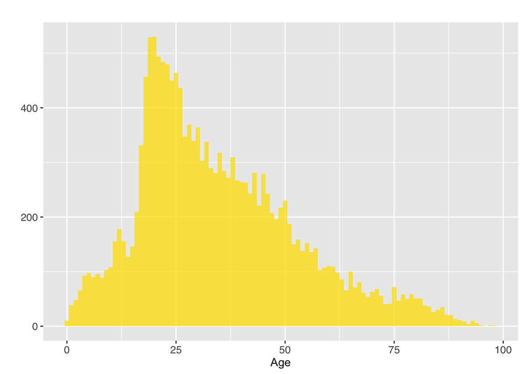

```r
ggplot(road, aes(Age.of.Casualty)) + # Initialise plot and set the x-axis to casualty age
    geom_histogram(binwidth=1, fill="#fddf00", alpha=0.75) + # Set width, colour and size
    labs(title="", x="Age", y="") + # Add a label for the x-axis, leave y-axis and title blank
    theme(axis.text = element_text(size=10, family="Helvetica")) # Set font type and size
```

Remove the variables we’re not interested in for this model - Reference Number, Grid References, Lat, Long, Accident Date and Column Number. To check out each of the variables and what they mean, see the guidance.csv file

```r
road$Reference.Number <- NULL
road$Accident.Date <- NULL
road$Easting <- NULL
road$Northing <- NULL
road$Latitude <- NULL
road$Longitude <- NULL
road$Col.Number <- NULL
```

## Correlation

In this practical demo of correlation, a core aspect of statistics - we’ll find out the correlation between Casualty Severity and Number of Vehicles, as well as the correlation between variables. A quick reminder - a negative result indicates a negative correlation, while a positive result indicates a positive relationship. In the next step we’ll be investigating Casualty Severity. This step should not be used as a substitute for signficance tests, which we’ll move onto next in the Linear Regression section.

```r
cor(road$Casualty.Severity, road$Number.of.Vehicles)
```

```
## [1] 0.1053375
```

But what if we want to find out and rank the correlation between variables? First, we need to install the necessary packages and build the correlation matrix

```r
install.packages("reshape2", repos = "http://cran.us.r-project.org")
install.packages("scales", repos = "http://cran.us.r-project.org")
library(reshape2)
library(scales)

Correlation <- cor(road)
```

Melt into long format. This is where the ‘melt’ and ‘reshape’ two packages come in

```r
Correlation_Melt <- melt(Correlation, varnames=c("x", "y"), value.name="Correlation")
```

Order according to correlation

```r
Correlation_Melt <- Correlation_Melt[order(Correlation_Melt$Correlation), ]
```

Display the melted data, which will rank the correlation between variables

```r
Correlation_Melt
```

```
##                        x                    y   Correlation
## 8         Casualty.Class   Number.of.Vehicles -0.3911647481
## 85    Number.of.Vehicles       Casualty.Class -0.3911647481
## 4        X1st.Road.Class   Number.of.Vehicles -0.2018913142
## 37    Number.of.Vehicles      X1st.Road.Class -0.2018913142
## 95       Age.of.Casualty       Casualty.Class -0.1378770285
## 128       Casualty.Class      Age.of.Casualty -0.1378770285
## 16       X1st.Road.Class Number.of.Casualties -0.1167245057
## 38  Number.of.Casualties      X1st.Road.Class -0.1167245057
## 71       Age.of.Casualty  Lighting.Conditions -0.1043899017
## 126  Lighting.Conditions      Age.of.Casualty -0.1043899017
## 93     Casualty.Severity       Casualty.Class -0.1014378663
## 104       Casualty.Class    Casualty.Severity -0.1014378663
## 23       Age.of.Casualty Number.of.Casualties -0.0804344220
## 122 Number.of.Casualties      Age.of.Casualty -0.0804344220
```

[output cut: 130 more lines]

You can create a heatmap showing the correlation between variables. When you create the plot in R, the x-axis may be muddled. To correct this, select ‘Zoom’ at the top left and widen the screen to see all the variables

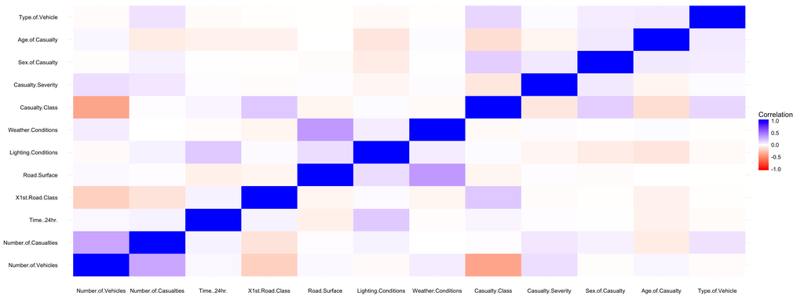

```r
ggplot(Correlation_Melt, aes(x=x, y=y)) + # initialise the plot and set axes
  geom_tile(aes(fill=Correlation)) + # Draw tiles and fill colour based on correlation
  scale_fill_gradient2(low="red", mid="white", high="blue", guide=guide_colorbar(ticks=FALSE), limits=c(-1,1)) + # Create a three tier gradient with a diverging colour scale and set the limits
  theme_minimal() + # Use minimal theme so there are no extras in the plot
  labs(x=NULL, y=NULL) # Remove labels of x and y axes
```

## Linear Regression & Multiple Linear Regression

What is Linear Regression? Linear regression is one of the most popular prediction methods for data scientists and statisticians. If you are looking to predict a numerical quantity like price or blood glucose levels, then linear regression is a good place to start. You can find our more about linear regression by following [this introduction](http://www.statisticssolutions.com/what-is-linear-regression/). There are many models to choose from, which means carefully selecting which is best for the problem as well as the data you’re working with. To find out a bit more about statistical model building visit this [flowchart](http://www.datasciencecentral.com/profiles/blogs/how-to-choose-a-statistical-model).

Build the linear model, with Casualty Severity as our dependent variable and age as the single independent variable. This is done using the lm function

```r
linear_model <- lm(Casualty.Severity ~ Age.of.Casualty, data = road)
```

Print the results of the model. To find out how to interpret the results, you have a number of options. First you can use the help function help(summary.lm) or try online. The following [link](http://blog.yhat.com/posts/r-lm-summary.html) gives a nice overview.

```r
print(summary(linear_model))
```

```
##
## Call:
## lm(formula = Casualty.Severity ~ Age.of.Casualty, data = road)
##
## Residuals:
##     Min      1Q  Median      3Q     Max
## -1.9049  0.1085  0.1163  0.1281  0.1715
##
## Coefficients:
##                   Estimate Std. Error t value Pr(>|t|)
## (Intercept)      2.9057273  0.0059178 491.016  < 2e-16 ***
## Age.of.Casualty -0.0007879  0.0001505  -5.237 1.66e-07 ***
## ---
## Signif. codes:  0 '***' 0.001 '**' 0.01 '*' 0.05 '.' 0.1 ' ' 1
##
## Residual standard error: 0.3486 on 16220 degrees of freedom
## Multiple R-squared:  0.001688,   Adjusted R-squared:  0.001626
## F-statistic: 27.42 on 1 and 16220 DF,  p-value: 1.655e-07
```

But what if we want to find out the significance of other variables? Let’s do that here with a multiple linear regression model

```r
linear_model_2  <- lm(Casualty.Severity ~ Age.of.Casualty + Weather.Conditions + Road.Surface + Lighting.Conditions + Sex.of.Casualty + Type.of.Vehicle + Number.of.Vehicles, data = road)
```

To test the significance of all variables, a shorter version of the code can be used:

```r
linear_model_2 <- lm(Casualty.Severity~., data = road)
```

Again, let’s print the results of our second linear model

```r
print(summary(linear_model_2))
```

```
##
## Call:
## lm(formula = Casualty.Severity ~ ., data = road)
##
## Residuals:
##      Min       1Q   Median       3Q      Max
## -2.01394  0.05798  0.10798  0.14614  0.33121
##
## Coefficients:
##                        Estimate Std. Error t value Pr(>|t|)
## (Intercept)           2.818e+00  1.913e-02 147.287  < 2e-16 ***
## Number.of.Vehicles    2.192e-02  3.790e-03   5.783 7.48e-09 ***
## Number.of.Casualties  1.345e-02  2.194e-03   6.130 8.96e-10 ***
## Time..24hr.           7.656e-06  5.270e-06   1.453  0.14633
## X1st.Road.Class       4.148e-03  1.672e-03   2.481  0.01310 *
## Road.Surface          3.494e-03  5.068e-03   0.689  0.49057
## Lighting.Conditions  -6.556e-03  1.414e-03  -4.637 3.57e-06 ***
## Weather.Conditions    2.524e-03  2.741e-03   0.921  0.35714
## Casualty.Class       -5.319e-02  4.253e-03 -12.506  < 2e-16 ***
## Sex.of.Casualty       6.162e-02  5.627e-03  10.950  < 2e-16 ***
## Age.of.Casualty      -1.222e-03  1.524e-04  -8.018 1.14e-15 ***
## Type.of.Vehicle       1.158e-03  3.733e-04   3.101  0.00193 **
## ---
## Signif. codes:  0 '***' 0.001 '**' 0.01 '*' 0.05 '.' 0.1 ' ' 1
##
## Residual standard error: 0.3436 on 16210 degrees of freedom
## Multiple R-squared:  0.03076,    Adjusted R-squared:  0.0301
## F-statistic: 46.77 on 11 and 16210 DF,  p-value: < 2.2e-16
```

Ok, now I’m going to create a model with Number of Casualties as the dependent variable so we can compare the two

```r
linear_model_3 <- lm(Number.of.Casualties~., data = road)
print(summary(linear_model_3))
```

```
##
## Call:
## lm(formula = Number.of.Casualties ~ ., data = road)
##
## Residuals:
##     Min      1Q  Median      3Q     Max
## -4.3987 -0.7517 -0.4066  0.3678 10.8118
##
## Coefficients:
##                       Estimate Std. Error t value Pr(>|t|)
## (Intercept)          6.133e-02  1.046e-01   0.586 0.557668
## Number.of.Vehicles   5.412e-01  1.288e-02  42.006  < 2e-16 ***
## Time..24hr.          5.674e-05  1.884e-05   3.012 0.002602 **
## X1st.Road.Class     -6.114e-02  5.959e-03 -10.261  < 2e-16 ***
## Road.Surface         1.893e-02  1.812e-02   1.045 0.296059
## Lighting.Conditions  2.884e-02  5.054e-03   5.707 1.17e-08 ***
## Weather.Conditions  -3.271e-02  9.798e-03  -3.338 0.000845 ***
## Casualty.Class       2.370e-01  1.517e-02  15.625  < 2e-16 ***
## Casualty.Severity    1.720e-01  2.805e-02   6.130 8.96e-10 ***
## Sex.of.Casualty      8.045e-02  2.018e-02   3.986 6.76e-05 ***
## Age.of.Casualty     -5.553e-03  5.443e-04 -10.202  < 2e-16 ***
## Type.of.Vehicle      1.493e-02  1.330e-03  11.223  < 2e-16 ***
## ---
## Signif. codes:  0 '***' 0.001 '**' 0.01 '*' 0.05 '.' 0.1 ' ' 1
##
## Residual standard error: 1.229 on 16210 degrees of freedom
## Multiple R-squared:  0.1344, Adjusted R-squared:  0.1338
## F-statistic: 228.9 on 11 and 16210 DF,  p-value: < 2.2e-16
```

To compare the two regression models visually we need to install the ‘coefplot’ package

```r
install.packages("coefplot", repos = "http://cran.us.r-project.org")
library(coefplot)
```

We can plot the coefficients of one of the linear models - in this case the second linear model for Casualty Severity

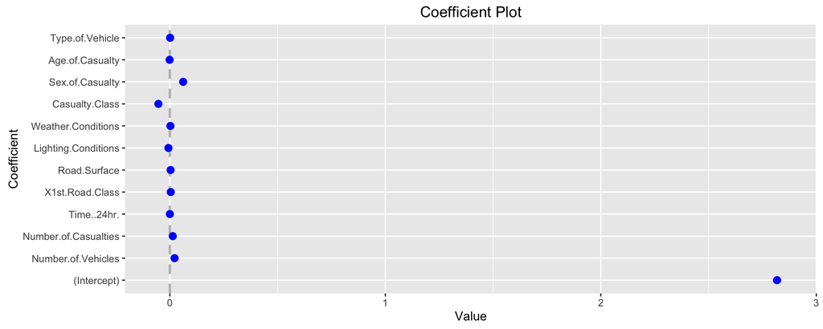

```r
coefplot(linear_model_2)
```

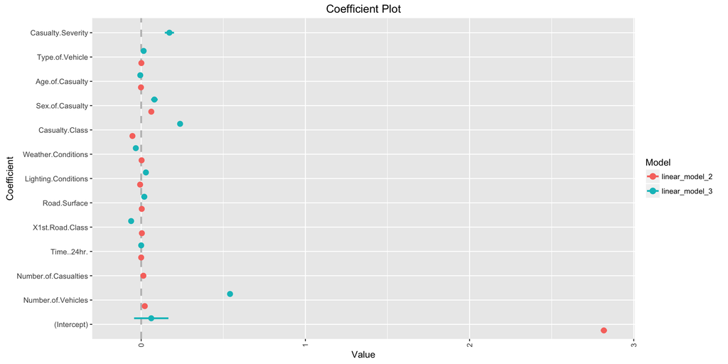

```r
multiplot(linear_model_2, linear_model_3)
```

## Summary

[figure not shown]